# Chocolate

```r
View(choc)
?choc
```

## Background

This analysis is trying to help the new chocolate bar manufacturers. The manufacturers can make various darkness types of chocolate bars by choosing a certain type of cacao bean. There are 41 types of cacao beans. This analysis will find out if different types of cacao beans are used with different content in a different bar of chocolate. To find a certain type of cacao bean will be beneficial for a new manufacturer to start with because it can make various darkness of chocolate bars. The analysis will be practiced with the five most common cacao beans to make bars of chocolate. The table’s first five types of cacao beans are showing the most commonly used types of cacao beans to the least.

```r
choc1 <- choc %>% mutate(Cocao = parse_number(Cocao), na.rm = TRUE)
#table(choc1$Type) %>% pander()
View(choc1)

choc2 <- choc1 %>% group_by(Type) %>% summarise(numbers = n()) %>% arrange(desc(numbers))

View(choc2)
datatable(choc2, options=list(lengthMenu = c(5,10)), extensions="Responsive")
```

|  | Type | numbers |
| --- | --- | --- |
| 1 | A | 887 |
| 2 | Trinitario | 419 |
| 3 | Criollo | 153 |
| 4 | Forastero | 87 |
| 5 | Forastero (Nacional) | 52 |
| 6 | Blend | 41 |
| 7 | Criollo, Trinitario | 39 |
| 8 | Forastero (Arriba) | 37 |
| 9 | Criollo (Porcelana) | 10 |
| 10 | Trinitario, Criollo | 9 |

[output cut: 31 more lines]

```r
choc3 <- choc1 %>% filter(Type %in% c("A", "Trinitario", "Criollo", "Forastero", "Forastero (Nacional)"))
View(choc3)
```

## Analysis

$\text{The Kruskal-Wallis Rank Sume Test}$ (non-parametric test) will be used in this analysis because the distributions of the data are not normal and the data are coming from more than two samples. However, the analysis assumes the samples come from the same population.

The null hypothesis and the alternative hypothesis can be written as

$$H_{0}: \text{The content of bars of chocolate with top five commonly used types of cacao beans all come from}$$
$$\text{the same distribution}$$
$$H_{a}: \text{At least one type of cacao bean is used with different content in a bar of chocolate}$$

The level of significance is $\alpha = 0.05$

```r
kruskal.test(Cocao ~ Type, data = choc3)
```

```
##
##  Kruskal-Wallis rank sum test
##
## data:  Cocao by Type
## Kruskal-Wallis chi-squared = 4.2095, df = 4, p-value = 0.3784
```

$\star$ Kruskal-Wallis Rank Sum Test uses chi-squared distribution because the Kruskal-Wallis Rank Sum Test distribution is similar to it. So, the $p-value$ is an approximate value.

The test result appears that the $p-value$, 0.3784 is higher than the level of significance, $\alpha = 0.05$. So, the null hypothesis is failed to reject. That is, the top five different types of cacao beans are used with the same content in different bars of chocolate. The following graphic displays the data.

## Graph

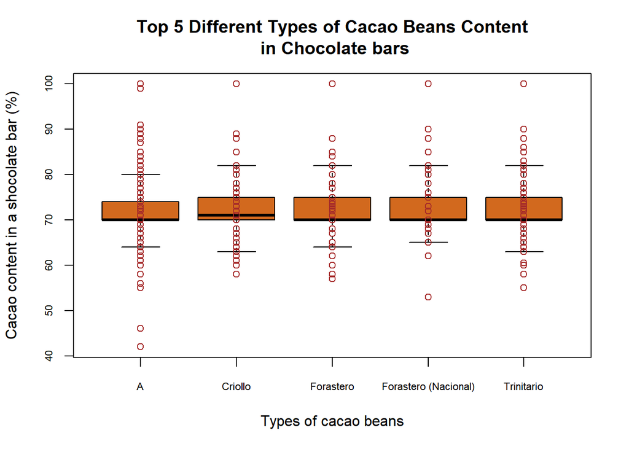

```r
boxplot(Cocao ~ Type, data = choc3, ylab = "Cacao content in a shocolate bar (%)", cex.axis = 0.7, xlab = "Types of cacao beans", main = "Top 5 Different Types of Cacao Beans Content\n in Chocolate bars", col = "chocolate")
stripchart(Cocao ~ Type, data = choc3, col = "brown", add = TRUE, pch = 1, vertical = TRUE, jitter = TRUE)
```

```r
pander(favstats(Cocao ~ Type, data = choc3)[,-10], caption = "Top 5 Different Types of Cacao Beans Content in a Chocolate bar")
```

Top 5 Different Types of Cacao Beans Content in a Chocolate bar

| Type | min | Q1 | median | Q3 | max | mean | sd | n |
| --- | --- | --- | --- | --- | --- | --- | --- | --- |
| A | 42 | 70 | 70 | 74 | 100 | 71.56 | 6.546 | 887 |
| Criollo | 58 | 70 | 71 | 75 | 100 | 72.01 | 5.767 | 153 |
| Forastero | 57 | 70 | 70 | 75 | 100 | 72.06 | 6.585 | 87 |
| Forastero (Nacional) | 53 | 70 | 70 | 75 | 100 | 73.02 | 7.485 | 52 |
| Trinitario | 55 | 70 | 70 | 75 | 100 | 71.74 | 5.322 | 419 |

## Conclusion

The Kruskal-Wallis Rank Sum Test result shows that the top five commonly used types of cacao beans content in a chocolate bar have similar content to the other chocolate bars. The graph and the table show that the first quartile, the median, and the third quartile are almost equal.

The type of cacao bean does not affect content to make a bar of chocolate. The new chocolate bar manufacturers can use any type of cacao beans to make chocolate bars in general. But referring to the graph, the only difference is that the type “A” cacao bean can be used with more varied content in the chocolate bars. There will be not a big difference choosing the other types of cacao beans, but type “A” cacao bean can give more various chocolate bar darkness options for a new manufacturer.